# COVID-19 in Newfoundland and Labrador

Dr. Amy Hurford

[Memorial University of Newfoundland and Labrador,](https://www.mun.ca/math/) [Canadian Network for Modelling Infectious Disease,](https://canmod.net/) [Mathematics for Public Health,](http://www.fields.utoronto.ca/activities/public-health) [One Health Modelling Network for Emerging Infections](https://www.yorku.ca/science/cdm/2021/04/09/ccdm-network-to-model-emerging-infectious-diseases-receives-2-5-million-in-federal-funding/)

In February 2022, 22$\%$ of tests reported by the Newfoundland and Labrador provincial PCR testing system were positive. *Could this high percentage of positive test results suggest that COVID-19 is increasing undetected in the Newfoundland and Labrador community?*

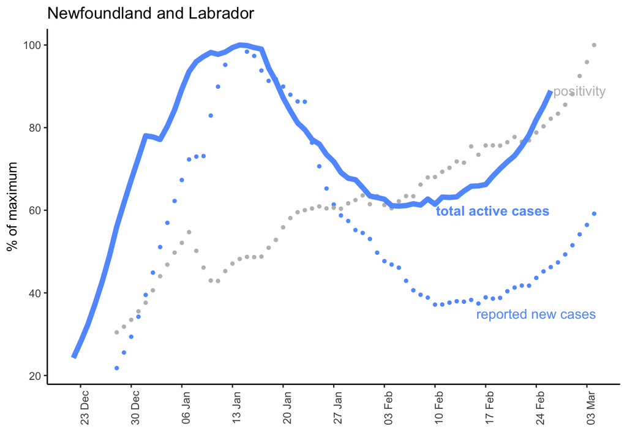

**Figure 1. Each of % positivity (grey dots), total active cases (reported and unreported; blue line), and reported new cases (blue dots) are plotted relative to their maximum values, so that *trends* can be compared.** Recently, the percentage of tests that are positive, as reported by the provincial testing system, has been near its maximum value (grey dots; 14-day average). In contrast, reported new cases peaked in mid-January, reached a low in mid-February, and are currently increasing (blue dots; 14-day average as a % of the maximum value). While positivity values have been high, trends in total active cases and reported new cases (i.e., increasing, decreasing, or level) have been similar. Reported cases and test positivity are used to calculate undetected cases 7 days ago, so total active cases (blue solid line) can only be estimated up until 7 days before the last reported data. Data are from the [Department of Health and Community Services Public Advisories](https://www.gov.nl.ca/releases/covid-19-news/).

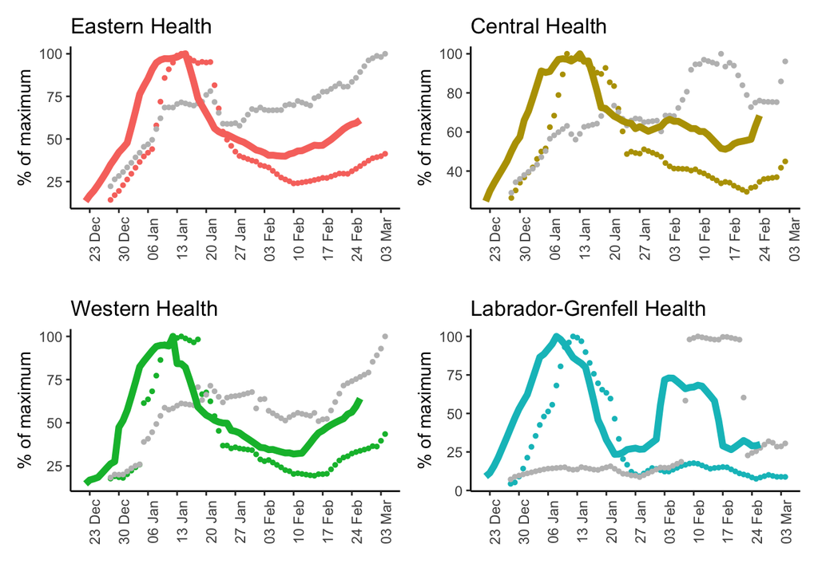

**Figure 2. Each of % positivity (grey dots), total active cases (reported and unreported; coloured line), and reported new cases (coloured dots) are plotted relative to their maximum values for each Regional Health Authority.** Data are from the [Newfoundland and Labrador COVID-19 Pandemic Update Hub](https://geohub-gnl.hub.arcgis.com/search?q=COVID) as the public advisories do not report test numbers for each Regional Health Authority.

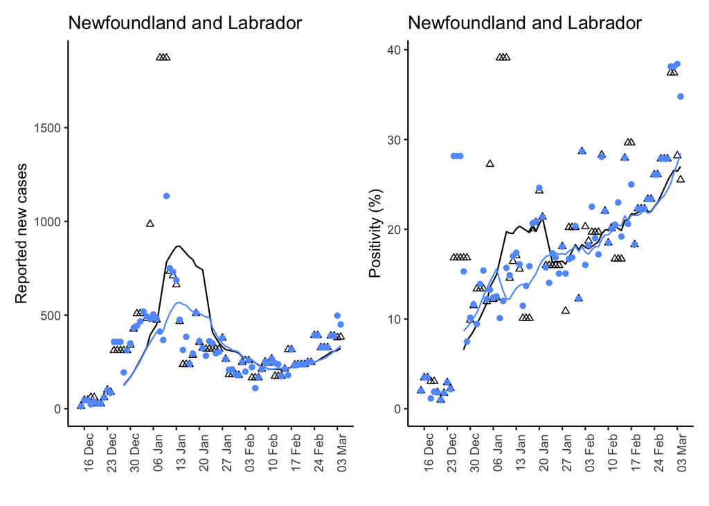

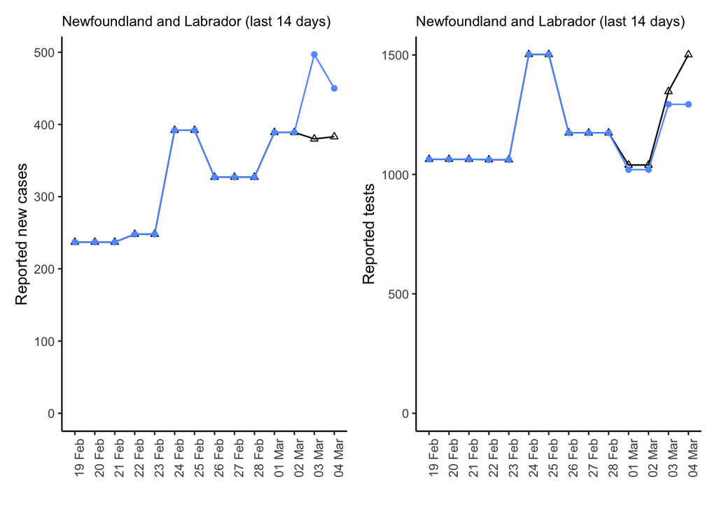

**Figure 4. Reported new cases (left) and tests (right) used for this analysis (last 14 days only).** Both the [Department of Health and Community Services Public Advisories](https://www.gov.nl.ca/releases/covid-19-news/) (blue line and dots) and [Newfoundland and Labrador COVID-19 Pandemic Update Hub](https://geohub-gnl.hub.arcgis.com/search?q=COVID) (black line and open triangles) data are shown in both panels, but the data are similar.

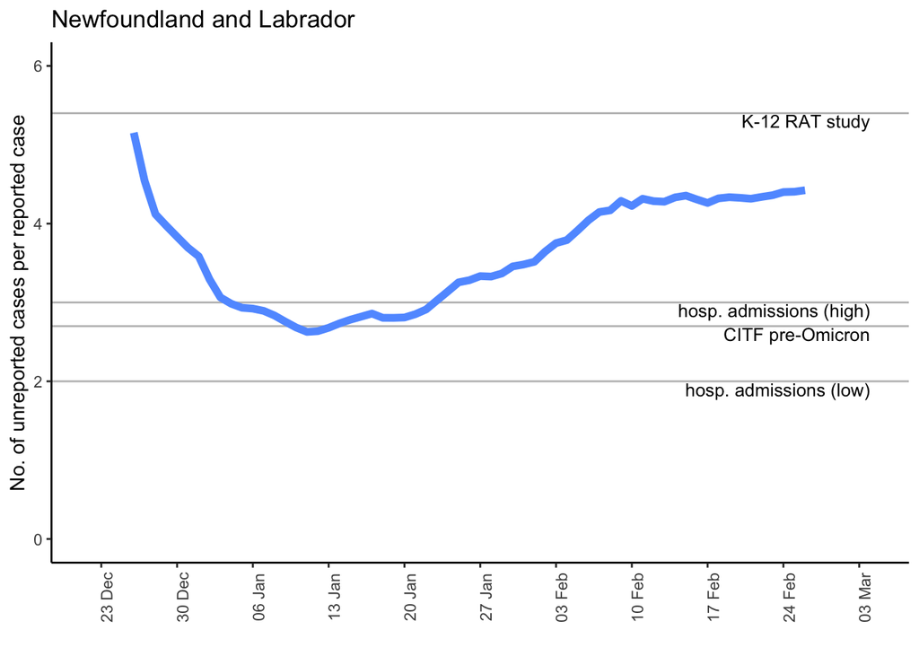

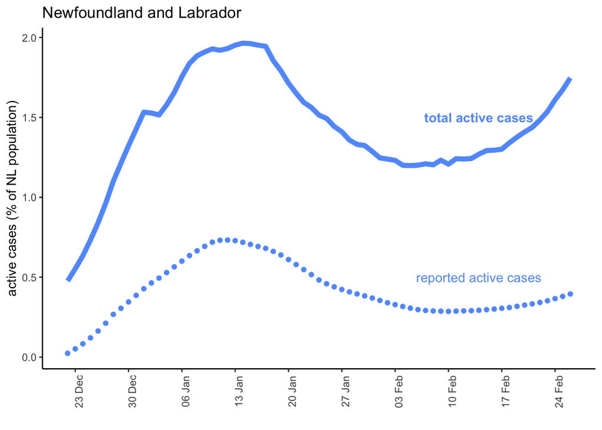